# 2026 IT Prof Conf Data Report

Spencer Bailey

### Conference Registration and Attendance Metrics

#### Daily Registration Counts:

These first two charts represent registration of all attendees over the registration period, highlighting dates of targeted marketing efforts (CIO Office Hour Announcements, Campus Newsletter Announcements, InsideUW Ads, etc…). The first chart represents our registration punctuated by marketing efforts made through various campus newsletters. The second chart depicts our registrations punctuated by all remaining outreach efforts labeled descriptively. The goal in analyzing this data is to aid in strategically leveraging communication channels for the greatest outreach in future conference iterations.

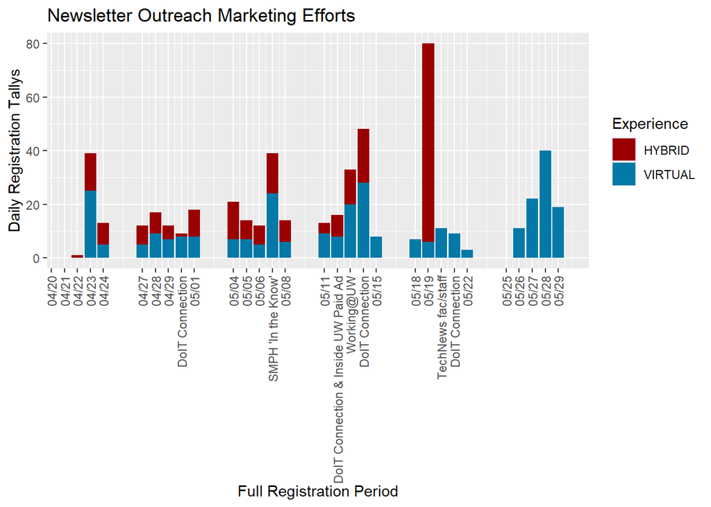

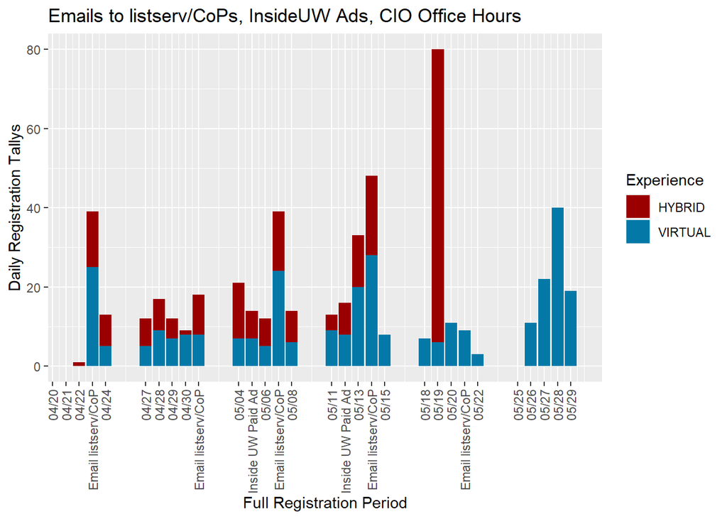

From these two charts, it appears that the most successful marketing efforts to garner registrations is through our emails to listserv. The second graph shows that that emails sent to our listserves coincided with weekly registration highs.

#### Demographic counts for registrants:

These next two charts represent demographic information about conference registrants. The first two charts break down registrants by their School/College/Division. The second two charts breaks registrants down by their position titles - which isn’t complete as manually mapping all titles poses a big challenge and the data was subjected to some arbitrary groupings. The goal, however, in analyzing this demographic data in depth is to get a better sense of who our participants are, so that we might be able to, in future conference planning, identify what our primary participants might be most interested in to drive up our engagement.

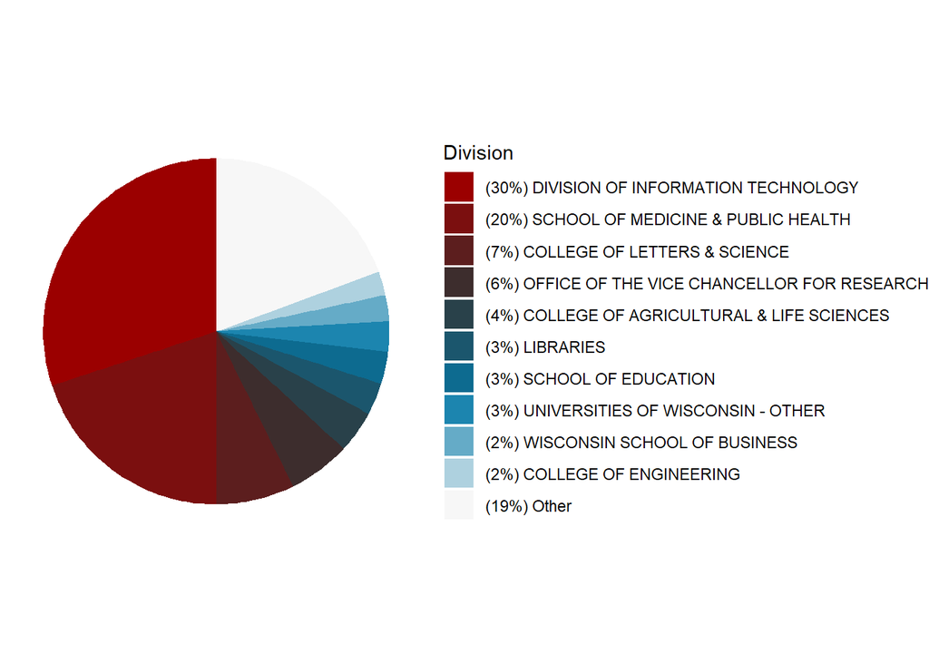

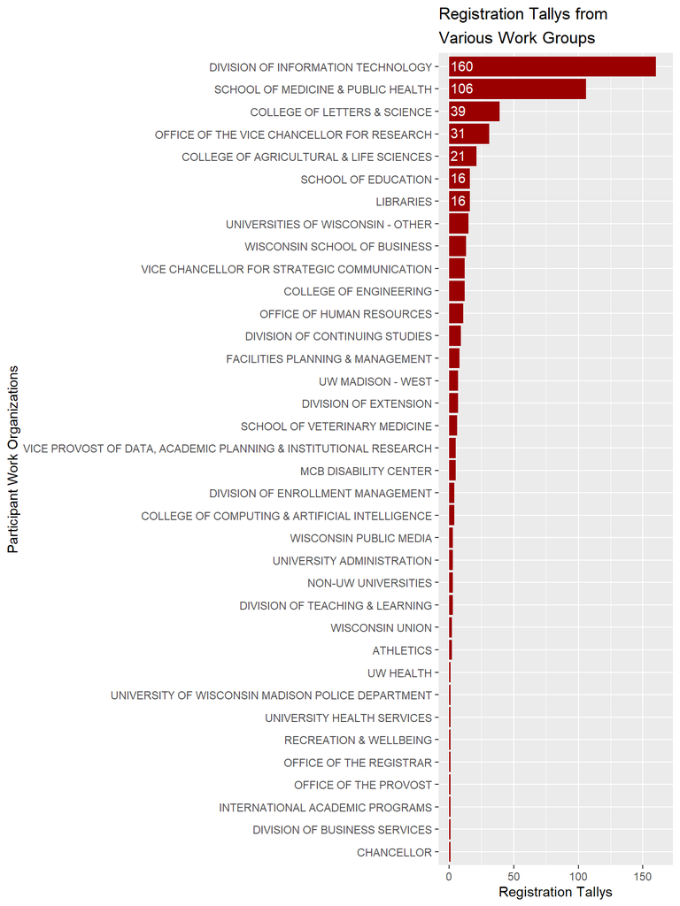

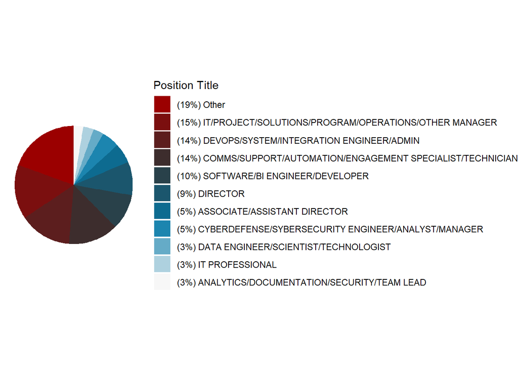

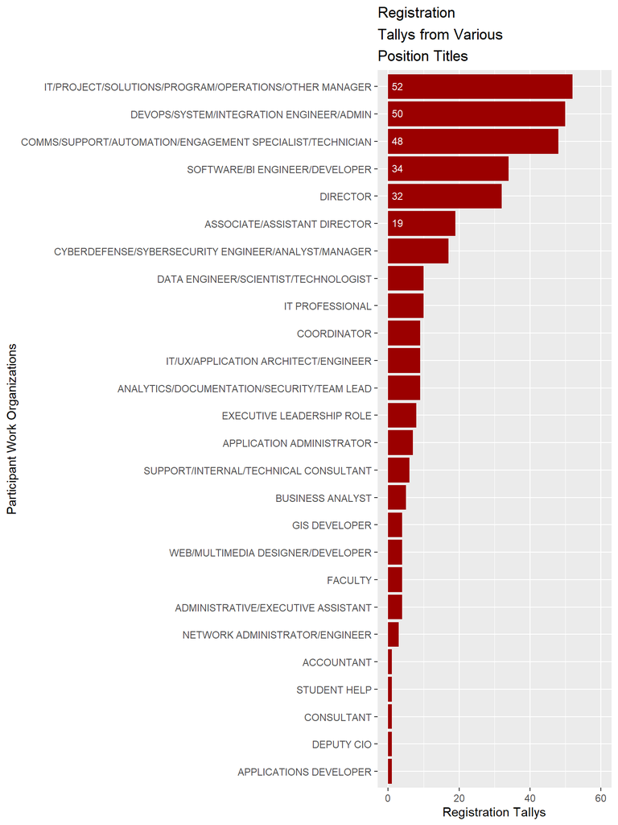

This data is not quite as neatly compiled and is a bit more arbitrary based on how titles were grouped, but is worth looking into anyway. A key observation here is our top 5 represented titles at the conference. The largest position group within the sample was Managers of various types. Though they make up a smaller proportion of our IT Professionals, they comprise a large proportion of our attendees. Our conference also attracted a good number of engineers and admins across various areas, General IT Professionals/Technicians/Support Persons, Developers, and Directors and Associate/Assistant Directors.

Although managers and directors make up a much smaller population of campus employees, together they represent the greatest proportion of conference attendees. Software Developers make up another large proportion of conference attendees, as do support persons. Increasing our breadth of content may be able to bring numbers up for smaller represented title groups.

#### Total attendee/registrant counts with comparison to previous year(s):

[output not shown]

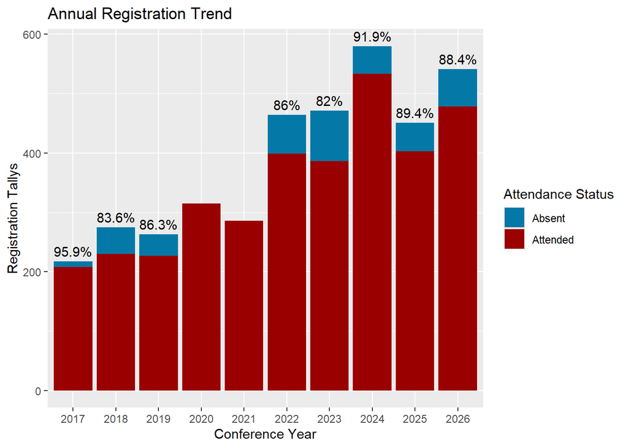

### Session Attendance Metrics

#### Total Attendance Recorded Throughout the Day:

The two following graphs here will portray attendance throughout the day of each conference day, to determine how strongly our attendance counts hold from earlier sessions to later sessions. This insight is valuable as it reveals when peak attendance times are during our conference days.

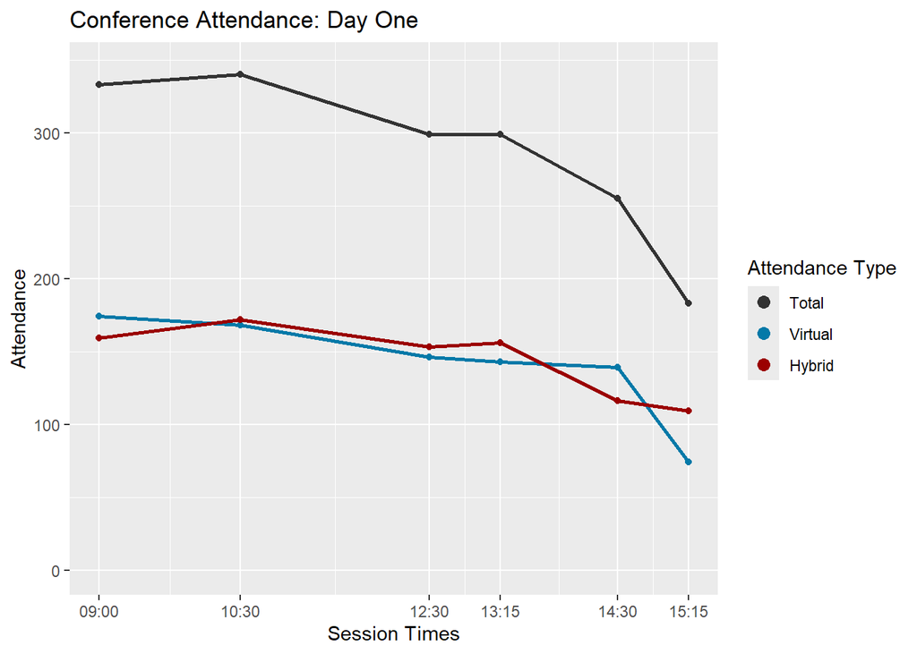

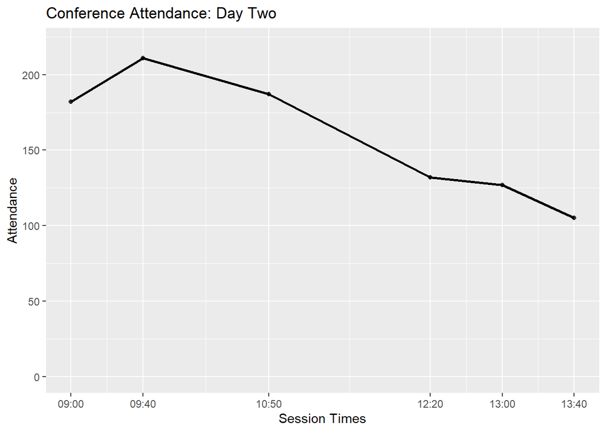

What’s notable in this section is that we see just over 300 live participants at our max despite having 469 engaged participants. This shows that we are definitely seeing some virtual individuals that attend only one or two sessions, or watch recordings later. Live participation is not indicative of our overall engagement. Continuing to maintain virtual options really helps individuals be able to participate and enjoy our sessions.

#### Breakdown of Total Attendance Throughout the Day by Session:

| Session Title | Total Attended | Attended Virtual | Attended In-Person |
| --- | --- | --- | --- |
| Keynote: Ideas Run the World. IT Powers the Journey. | 333 | 174 | 159 |
| IT Awards and Closing Remarks | 183 | 74 | 109 |
| AI Agents for IT Productivity | 130 | 68 | 62 |
| Building Trust in IT: Competency, Sincerity, and Care, Made Practical | 128 | 77 | 51 |
| Raised on Anime, Working in IT: How Japanese Anime Inspired Careers in IT and Cybersecurity | 127 | 60 | 67 |
| What Good Leadership Actually Looks Like. A Story About Mental Health, Trust, and Teams | 126 | 48 | 78 |
| Looking at How LLMs Might Help Your Work | 121 | 121 | 0 |
| From Listening to Doing: Exploring IT Federation Together | 112 | 53 | 59 |
| Building an AI Tutor With Google Tools | 90 | 90 | 0 |
| DNS and DHCP infrastructure at UW-Madison | 80 | 80 | 0 |
| How WiscWeb and StratComm Combined Forces to Bring us the UW Theme 2.0 | 75 | 38 | 37 |
| The Art of Adaptation: Real Stories of Navigating through Change | 65 | 31 | 34 |
| Get It Out Of Your Head: Your Brain Wasn’t Built for This (and Neither was Excel) | 65 | 38 | 27 |
| Normalizing Failure: How To Create Psychological Safety to Make Your Organization Successful | 64 | 30 | 34 |
| From ‘Do Something’ to Demystified: The Learn@UW Roadmap for Scaling AI Training | 63 | 38 | 25 |
| Kuali Build: Power Your Forms. Streamline Your Workflow. | 61 | 33 | 28 |
| Project Management for Messy People | 60 | 33 | 27 |
| Achieving Transparency in Organizational Culture Using No-Cost Automations | 57 | 57 | 0 |
| Continuous Improvisation: Adapting Process, Governance, and Communication in ITSM | 54 | 54 | 0 |
| How Containers Work Under the Hood | 51 | 51 | 0 |
| Simple Accessibility Wins in the KnowledgeBase | 50 | 50 | 0 |
| How I Used AI to Help with the IT Support Symposium | 49 | 27 | 22 |
| The Surprisingly Simple Tech Behind Digital Cinema | 48 | 48 | 0 |
| AI and You | 47 | 47 | 0 |
| So, You Need an Accessible Web Interface? | 47 | 47 | 0 |
| What Could Go Wrong? Building a Long-Term Archive in the Real World | 46 | 46 | 0 |
| Wardley Mapping: An Interactive Workshop to Map Strategic Planning | 43 | 22 | 21 |
| Replacing Spreadsheets: A Consolidated View of Network Infrastructure Data | 43 | 43 | 0 |
| How to Build Custom Blocks for the New UW Theme 2.0 | 37 | 37 | 0 |
| What Even is Technical Debt? | 35 | 35 | 0 |
| It’s Not You, It’s… Just Time: How to Breakup Well with Advanced Custom Fields | 30 | 30 | 0 |
| Utilizing AI Tools to Design and Develop Engaging Online Compliance Training for UW-Madison Staff, Faculty, and Students | 27 | 27 | 0 |
| DoH! How to implement DNS over HTTPS on Windows Server 2025 | 26 | 26 | 0 |
| Faster, Better and Cheaper: Refactoring Course Search & Enroll | 24 | 24 | 0 |
| Procurement, Personal Liability, and Possibly a Perfect Solution (9:00-9:15am) | 22 | 22 | 0 |
| Network with IT Mentors, Mentees and Friends | 15 | 0 | 15 |
| Unconference | 10 | 0 | 10 |
| Appreciating jj-vcs (12:20-12:35pm) | 9 | 9 | 0 |
| CANCELED-Resume Building in Modern Days | 0 | 0 | 0 |

#### Observations:

The first key observation in the session attendance are our top 5 attended sessions. They keynote had the highest turnout, as it is likely that many were interested in our main event. The IT Recognition Awards was the second most attended session, many likely enjoy seeing the work of our most valued professionals.Our third place goes to “AI Agents for IT Productivity”, fourth to “Building Trust in IT: Competency, Sincerity, and Care, Made Practical”, and fifth to “Raised on Anime, Working in IT: How Japanese Anime Inspired Careers in IT and Cybersecurity”.

One interesting note here is that our top three sessions follow with what we saw last year. Our first most attended session last year was the Keynote, the second was the IT Awards, and the third was an AI centered session. It was also interesting to see that people were really interested in the Anime session, as that was a rather unique session that interested a lot of individuals. More niche sessions should be included in our conference to shake up the typical project reporting and service oriented presentations.

Another observation made in this data is the decline of participation as the conference carries through the day. It is likely that some people attend only to see our keynote presentations and a few sessions after and return to work the rest of the afternoon.

A final observation here with the session attendance data is that networking and the unconference had pretty low attendance.

### Financial Reporting

This section shows high level budget information available in our 2026 Budgeting Sheet.

| Budget_Allocation | Registration_Revenue | Total_Budget |
| --- | --- | --- |
| $12,000 | $6,500 | $18,500 |

| Facility_Cost | Catering_Cost | Keynote_Speaker_Fee | Printing | Captioning | Advertising | Total |
| --- | --- | --- | --- | --- | --- | --- |
| $700.00 | $6,908.00 | $0.00 | $1,254.99 | $0.00 | $300.00 | $9,162.99 |